# Problem Statement:

## Outliers Treatment

### Lets check the percentage of Outliers with IQR

```python
outlier_num = tourismDf.select_dtypes(include=np.number)

# find the 25th percentile and 75th percentile.
Q1 = tourismDf.quantile(0.25)
Q3 = tourismDf.quantile(0.75)

# Inter Quantile Range (75th percentile - 25th percentile)
IQR = Q3 - Q1

# find lower and upper bounds for all values. All values outside these bounds are outliers
lower=Q1-1.5*IQR
upper=Q3+1.5*IQR

((outlier_num<lower)|(outlier_num>upper)).sum()/len(tourismDf)*100
```

```
ProdTaken                   18.821604
Age                          0.000000
DurationOfPitch              0.040917
NumberOfPersonVisiting       0.061375
NumberOfFollowups            6.382979
NumberOfTrips                2.229951
NumberOfChildrenVisiting     0.000000
MonthlyIncome                7.058101
dtype: float64
```

**Observations:**

1. MonthlyIncome and NumberOfFollowups have high outliers.
2. DurationOfPitch and NumberOfTrips also have few outliers.
3. ProductTaken is the target variable, it is not valid here for outlier treatment.
4. Since we are building DecisionTree Based models and they are not influenced by Outliers, we can choose either choose to treat or not to treat.
5. I am choosing to treat these outliers.

#### Handling Outliers in MonthlyIncome Data

##### Detecting outliers using box plot

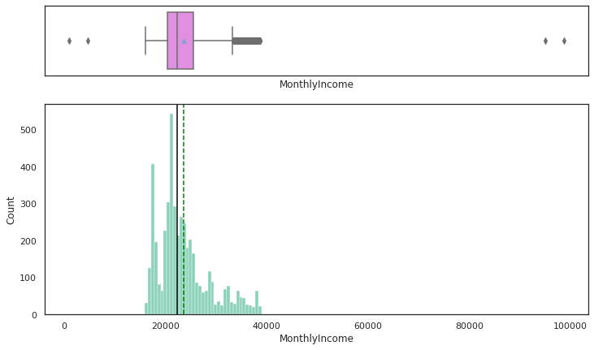

```python
histogram_boxplot(tourismDf,'MonthlyIncome')
```

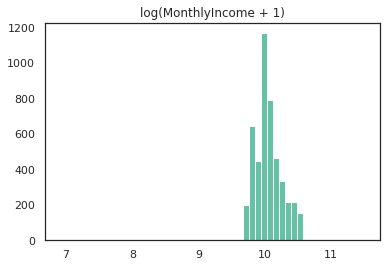

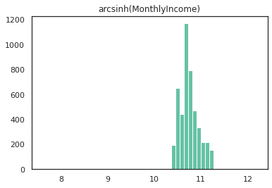

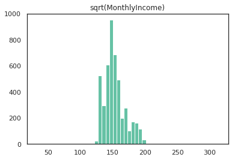

```python
plt.hist(np.log(tourismDf['MonthlyIncome'] + 1), 50)
plt.title('log(MonthlyIncome + 1)')
plt.show()
plt.hist(np.arcsinh(tourismDf['MonthlyIncome']), 50)
plt.title('arcsinh(MonthlyIncome)')
plt.show()
plt.hist(np.sqrt(tourismDf['MonthlyIncome']), 50)
plt.title('sqrt(MonthlyIncome)')
plt.show()
```

The log transformation decreases the scale of the distributions, even with the huge range of MonthlyIncome. It seems the outliers caused the log-transformed distributions to still be a bit skewed.

```python
tourismDf.insert(9,"log_Income",np.log(tourismDf["MonthlyIncome"]))
tourismDf.sample(n=10, random_state=1)
```

|  | ProdTaken | Age | TypeofContact | CityTier | DurationOfPitch | Occupation | Gender | NumberOfPersonVisiting | NumberOfFollowups | log_Income | ProductPitched | PreferredPropertyStar | MaritalStatus | NumberOfTrips | Passport | PitchSatisfactionScore | OwnCar | NumberOfChildrenVisiting | Designation | MonthlyIncome |
| --- | --- | --- | --- | --- | --- | --- | --- | --- | --- | --- | --- | --- | --- | --- | --- | --- | --- | --- | --- | --- |
| 3015 | 0 | 27.0 | Company Invited | 1 | 7.0 | Salaried | Female | 4 | 6.0 | 10.045074 | Basic | 3.0 | Married | 5.0 | 0 | 4 | 1 | 3.0 | Executive | 23042.0 |
| 1242 | 0 | 40.0 | Self Enquiry | 3 | 13.0 | Small Business | Male | 2 | 3.0 | 10.458320 | King | 4.0 | Single | 2.0 | 0 | 4 | 1 | NaN | VP | 34833.0 |
| 3073 | 0 | 29.0 | Self Enquiry | 2 | 15.0 | Small Business | Male | 4 | 5.0 | 10.069595 | Basic | 3.0 | Married | 3.0 | 0 | 2 | 0 | 2.0 | Executive | 23614.0 |
| 804 | 0 | 48.0 | Company Invited | 1 | 6.0 | Small Business | Male | 2 | 1.0 | 10.369891 | Super Deluxe | 3.0 | Single | 3.0 | 0 | 2 | 0 | 0.0 | AVP | 31885.0 |
| 3339 | 0 | 32.0 | Self Enquiry | 1 | 18.0 | Small Business | Male | 4 | 4.0 | 10.146865 | Deluxe | 5.0 | Divorced | 3.0 | 1 | 2 | 0 | 3.0 | Manager | 25511.0 |
| 3080 | 1 | 36.0 | Company Invited | 1 | 32.0 | Salaried | Female | 4 | 4.0 | 9.937889 | Basic | 4.0 | Married | 3.0 | 1 | 3 | 0 | 1.0 | Executive | 20700.0 |
| 2851 | 0 | 46.0 | Self Enquiry | 1 | 17.0 | Salaried | Male | 4 | 4.0 | 9.967964 | Basic | 3.0 | Divorced | 5.0 | 0 | 5 | 1 | 1.0 | Executive | 21332.0 |
| 2883 | 1 | 32.0 | Company Invited | 1 | 27.0 | Salaried | Male | 4 | 4.0 | 10.257730 | Standard | 3.0 | Divorced | 5.0 | 0 | 3 | 1 | 1.0 | Senior Manager | 28502.0 |
| 1676 | 0 | 22.0 | Self Enquiry | 1 | 11.0 | Salaried | Male | 2 | 1.0 | 9.760079 | Basic | 4.0 | Married | 2.0 | 1 | 4 | 1 | 0.0 | Executive | 17328.0 |
| 1140 | 0 | 44.0 | Self Enquiry | 1 | 13.0 | Small Business | Female | 2 | 3.0 | 10.435556 | King | 3.0 | Married | 1.0 | 1 | 4 | 1 | 1.0 | VP | 34049.0 |

```python
tourismDf.log_Income.describe()
```

```
count    4655.000000
mean       10.046740
std         0.213016
min         6.907755
25%         9.920640
50%        10.014447
75%        10.149214
max        11.499617
Name: log_Income, dtype: float64
```

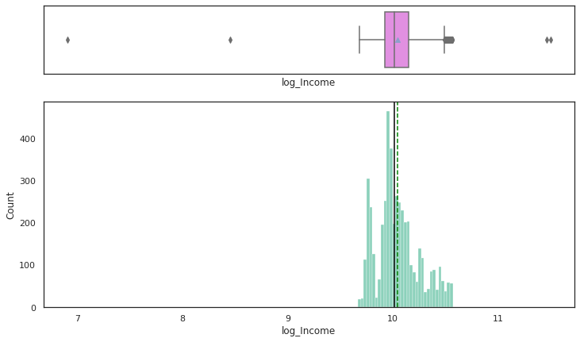

```python
histogram_boxplot(tourismDf,'log_Income')
```

```python
tourismDf.drop('log_Income', axis =1, inplace=True)
```

The log transformation doesn't seem to help in treating the outliers, we can consider keeping the MonthlyIncomeField as it is and probably do binning.